# What makes a Hollywood film successful?

Joanna Andari, Karim Awad, Jiye Ren, Nirbhay Sharma, Qiuyue Zhang, Xiaoyan Zhou

8 October 2017

[output not shown]

[output not shown]

[output not shown]

```
##      Min.   1st Qu.    Median      Mean   3rd Qu.      Max.      NA's
##       162   1472666  12738545  30786900  35868324 362645141       211
```

## Section 1: Introduction

Outside of India, the US continues to lead the way in producing a substantial volume of films, accounting for an estimated US$10.7bn in box office revenues in 2016[^2]. Yet in contrast to Indian films, which principally serve a domestic audience, Hollywood films benefit from a global distribution network. This results in films having to cater for different audiences in different countries, overcoming issues varying from political censorship through to cultural sensitivities, to maximise their appeal and potential commercial success.

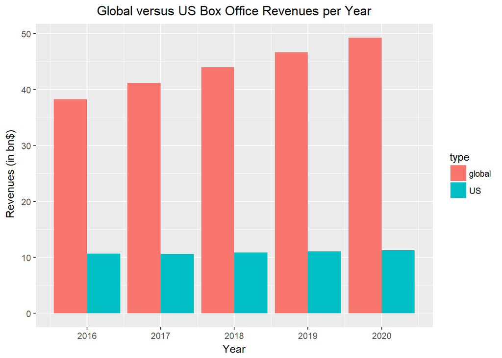

Although continued growth in China and India are likely to dominate global box office revenue growth until 2020, Hollywood is likely to remain a bellweather of judging a film’s global success, given its wide audience base. With that in mind, are there factors that can help predict a film’s popularity, and with that, guide future decisions on the types of films produced? In turn, can this better inform investors (and if applicable, governments) on potential risks involved with supporting particular projects?

This report seeks to examine a random sample of movie data pulled from IMDB data between 2011-16, concentrating on the US given its role in influencing the wider film industry. This will seek to understand how we should measure popularity, focusing on 2011-15 panel data, before devising a regression model that can help predict popularity. We will then test its capacity to predict 2016 trends, before noting the limitations of our work, and areas for further development.

## Section 2: Data sampling and cleaning

The data compiled for this project/analysis is obtained from 2 different datasets:

- **IMDB Movie Dataset**
- **Oscar Awards Dataset**

Given the lack of data on several variables, we have been creative with identifying particular financial and film-related characteristics. For instance, we have derived an ROI variable based on ticket sales divided by a film’s budget, to gauge the box office success of films. We have also derive genre dummies, based on the number of times a particular genre is mentioned for each film, to determine whether specific types of films are more popular than others. Finally, in an effort to gauge actor and director popularity, we have derived actor dummies for the lead and two foremost supporting actors, and a director dummy, both based on the number of times they appear within our sample. We have complemented this with separately pulling up Oscar data on both areas, as we recognise audience preferences are likely to change rather slowly over time (e.g. favourite actor, etc).

We discuss the merits of this approach throughout the report, along with commenting about potential limitations and improvements within Section 6.

## Section 3: How do we measure a film’s popularity?

### What metric(s) should we use to determine our dependent variable?

Determining what variable should represent popularity, itself a subjective quality, gives rise to several potential proxy variables. These can be divided between those that are financially driven relative to social media metrics, of which we consider each in turn, arriving at five possible variables.

An obvious proxy would be revenues, should we determine this a valid measure of commercial success. Contrary to the thoughts of those “voting with their wallets”, this is not entirely a straightforward metric. A limitation of the data available is we are only able to track box-office ticket sales, rather than all associated revenues. This ignores digital sales from streaming, DVD sales, and any other merchandise or commercial agreements (e.g. in-film advertising).

An example of this shortcoming would be the motion picture, “The Interview”. Although extreme given the political sensitivities with North Korea, which led to a limited global release, “The Interview grossed $40m in digital rentals…and earned an additional $11.2m worldwide at the box office on a $44m budget[^3]”. By relying on box office revenues alone, we may not get a complete view on how commercially successful a film has been. This is something we discuss further as a limitation within our work, but which we do not explore further.

A second issue is whether a low grossing film is still a success, relative to its underlying budget? This may be more applicable to arthouse films, rather than a typical Hollywood blockbuster, but is something we are able to condition against by examining a film’s return on investment; defined by its box office revenues divided by its total budget.

Social media provides us with three relevant metrics. The first surrounds the number of facebook likes a film has received. Although a singular expression of popularity, this provides some indication of fan reaction, premised on any “likes” resulting from watching the film, as opposed to being based on trailers or other promotional material. We are mindful this may not be entirely accurate, as we do not know at which point this data was collected (e.g. how many days / weeks after the film was released in the US, and how the latter is likely to vary by geography).

The remaining two metrics concern IMDB scores, and the number of votes received. IMDB scores should provide a direct measure of popularity, with our initial assumption based on this most likely to be normally distributed (i.e. this theoretically should capture a broad range of views between a ranking of 0-10). The number of users may also help quantify the depth of support, and depending on the distribution of IMDB scores, represent a useful proxy for capturing popularity.

### Descriptive analysis

We produce boxplots and density graphs of the five variables above, along with budget to provide a sense-check. These can all separately be found in the appendices.

```r
#stargazer(data11_15, type="latex", title="Table with Stargazer")

#temp_data <- data11_15 %>% select(gross, budget, num_voted_users, imdb_score, movie_facebook_likes, return)
#stargazer(temp_data, type="html", title="Summary of Dataset 2011 to 2015", median=TRUE, iqr=TRUE, nobs=FALSE, font.size="tiny", digits=2, align = TRUE, covariate.labels=c("Gross Revenue","Budget","No. of voted users","IMDB Score","Movie Facebook Likes","Movie ROI"))


#stargazer(summary(data11_15),type="latex", title="Table with Stargazer")
# iris_five %>% group_by(quintile) %>% # Group by quintile
#   summarize(mean_sepal_length = mean(Sepal.Length), mean_sepal_width = mean(Sepal.Width), count = n()) %>%
#   head()
```

```r
# imdbden <- ggplot(data=data11_15)+geom_density(aes(x=(imdb_score)))
# roibox <- ggplot(data=data11_15)+geom_boxplot(aes(x=1, y=return)) + ylim(0,5)
#
# grid.arrange(imdbden, roibox,  ncol=2)
```

There are several intriguing observations. Firstly we observe that all our variables except IMDB scores are positively skewed, with the latter negatively skewed. This confounds our earlier thoughts on IMDB scores being normally distributed. With a median score of 6.7, this implies fans are likely to respond with favourable views, especially with our 1st and 3rd quartile scores between 6.1 and 7.2 respectively. MOre generally, we will need to proceed with any regression analysis carefully (see further comments below).

Examining our financial metrics, our ROI variable suggests a median film will make a return of 1.2x, although this engenders significant volatility, reflected on our very wide range, and a standard deviation that would imply a negative mean on the downside. This seems consistent with the level of risk associated with producing films, with properties mimicking a financial option (e.g. an upfront payment with no certainty of exercise), given the uncertainty in audience receptiveness.

This uncertainty is reinforced in the range of revenue figures, and corresponding budget figures respectively. With revenue, this volatility is likely to be more pronounced in practice, as our metric only focuses on box office tickets. These figures imply a median film will have a budget of US$40m and be expected to generate box office revenues of US$52m, consistent with our ROI estimate above.

Our last observation is the comparative depth of number of IMDB votes relative to facebook likes. As alluded towards earlier, it is unclear how such facebook data has been collected, nor the interval between the film’s release and collection. The latter is equally applicable to IMDB scores; however, given the negative skew with this statistic, the higher number of votes may prove a more desirable proxy in gauging popularity. We shall seek to confirm this by testing how these variables correlate with each other, to guide our final choice on our dependent variables.

### Correlation analysis

|  | imdb_score | movie_facebook_likes | gross | return | budget | num_voted_users |
| --- | --- | --- | --- | --- | --- | --- |
| imdb_score | 1.00 | 0.47 | 0.29 | -0.07 | 0.15 | 0.53 |
| movie_facebook_likes | 0.47 | 1.00 | 0.53 | 0.01 | 0.38 | 0.80 |
| gross | 0.29 | 0.53 | 1.00 | 0.04 | 0.68 | 0.66 |
| return | -0.07 | 0.01 | 0.04 | 1.00 | -0.25 | -0.03 |
| budget | 0.15 | 0.38 | 0.68 | -0.25 | 1.00 | 0.52 |
| num_voted_users | 0.53 | 0.80 | 0.66 | -0.03 | 0.52 | 1.00 |

|  | imdb_score | movie_facebook_likes | gross | return | budget | num_voted_users |
| --- | --- | --- | --- | --- | --- | --- |
| imdb_score | NA | 0.0000000 | 0.0000000 | 0.1464951 | 0.0007002 | 0.0000000 |
| movie_facebook_likes | 0.0000000 | NA | 0.0000000 | 0.8599276 | 0.0000000 | 0.0000000 |
| gross | 0.0000000 | 0.0000000 | NA | 0.3643228 | 0.0000000 | 0.0000000 |
| return | 0.1464951 | 0.8599276 | 0.3643228 | NA | 0.0000000 | 0.5170522 |
| budget | 0.0007002 | 0.0000000 | 0.0000000 | 0.0000000 | NA | 0.0000000 |
| num_voted_users | 0.0000000 | 0.0000000 | 0.0000000 | 0.5170522 | 0.0000000 | NA |

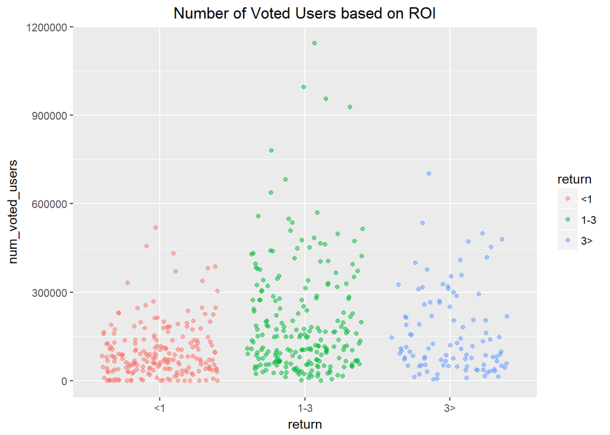

In contrast to revenues, we do not consider ROI as suitable for further analysis as a dependent variable. Revenues as a financial metric has demonstrated the positive relationships we expected to see amongst social media (e.g. facebook looks and number of voted users), indicating that expressions of support tend to correspond with higher box office revenues (i.e. people go to the cinema). We do note the more weak positive correlation with IMDB scores (esp. relative to number of voting IMDB users), which we suspect is a function of the latter’s negative skew, although given the strong correlation with budget, this partly offsets these concerns. The latter relationship would correspond well with blockbusters generating higher revenues, conditioned on budgets that can support the hiring of better actors, and increased marketing / promotional spend.

Equally, we observe a more positive correlation between number of voted users, against other metrics, relative to both IMDB scores and facebook likes. This warrants reappraising this variable, as it may represent a better proxy relative to IMDB scores themselves. From our descriptive analysis section above, we note a strong negative skew in IMDB scores, suggesting that those voting are likely to be fans conveying their support for a film, rather than providing a balanced critique. Therefore the number of IMDB votes may better represent the strength of popularity enjoyed by a particular movie. However, we are conscious of the possibility that not all these votes will be conveying the same numerical grade, nor the potential for duplicate votes to be included in any final score.

In sum, we believe examining both revenue and the number of IMDB votes separately, can help better inform our perspective on what constitutes a successful film. Yet both of these dependent variables demonstrate strong positive skew, which could bias any parameter estimate, and impact on variance calculations, affecting the accuracy of any t-statistic. Performing multiple regression analysis using OLS as it stands is unlikely to be appropriate. Remedies available are to perform regression using a GLS-based approach, or to transform our variables to resemble a normal distribution. Although extending beyond the scope of this assignment, we transform both our revenue and number of votes variables by natural logs raised to the power of 6 and 4 respectively (see below). As these transformations will generate beta estimates which are not intuitive, we conduct our regressions without these adjustment, altering our y-variable at the end to get a better understanding of our parameters and overall adjusted R-squared.

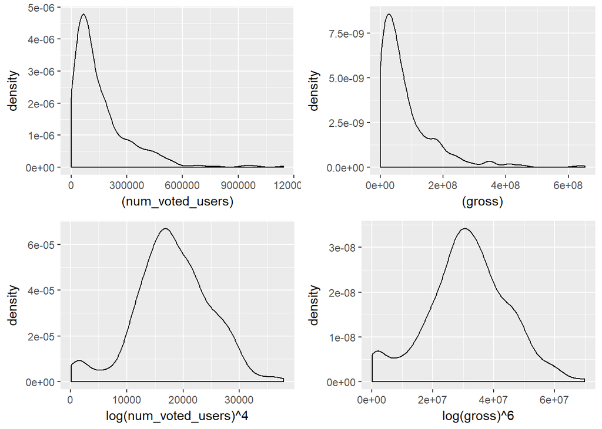

## Section 4: Regression Analysis

### Social media: Number of IMDB votes

```r
log4numvoted_users <- (log(data11_15$num_voted_users)^4)

usereg1 <- lm(data = data11_15, num_voted_users~gross)

usereg2 <- lm(data = data11_15, num_voted_users ~ gross +actor1_occurence+ actor2_occurence+ actor3_occurence)

usereg3 <- lm(data = data11_15, num_voted_users ~ gross +actor1_occurence+ director_occurence)

usereg4 <- lm(data = data11_15, num_voted_users ~ gross +actor1_occurence + movie_oscars + actor_oscars)

usereg5 <- lm(data = data11_15, num_voted_users ~ gross +actor1_occurence + duration + actor_oscars)

usereg6 <- lm(data = data11_15, num_voted_users ~ gross +actor1_occurence + duration + actor_oscars + actiondummy + adventuredummy + comedydummy +
                familydummy + fantasydummy+horrordummy+romancedummy + scifidummy+thrillerdummy)

usereg7 <- lm(data = data11_15, num_voted_users ~ gross +actor1_occurence + duration + actor_oscars + actiondummy + familydummy + romancedummy +
                scifidummy + thrillerdummy)

usereg8 <- lm(data = data11_15, num_voted_users ~ gross +actor1_occurence + duration + actor_oscars + familydummy + scifidummy )

usereg9 <- lm(data = data11_15, num_voted_users ~ gross + actor_oscars + familydummy + scifidummy)

usereg10 <- lm(data = data11_15, log4numvoted_users ~ gross + actor_oscars + familydummy + scifidummy)



stargazer(usereg1, usereg2, usereg3, usereg4, usereg5, usereg6, usereg7, usereg8, usereg9, usereg10, type = "html", report = "vct*")
```

|  | *Dependent variable:* |  |  |  |  |  |  |  |  |  |
| --- | --- | --- | --- | --- | --- | --- | --- | --- | --- | --- |
|  | num_voted_users |  |  |  |  |  |  |  |  | log4numvoted_users |
|  | (1) | (2) | (3) | (4) | (5) | (6) | (7) | (8) | (9) | (10) |
| gross | 0.001 | 0.001 | 0.001 | 0.001 | 0.001 | 0.001 | 0.001 | 0.001 | 0.001 | 0.00004 |
|  | t = 19.585*** | t = 17.536*** | t = 18.998*** | t = 19.311*** | t = 16.298*** | t = 14.751*** | t = 15.442*** | t = 15.692*** | t = 19.992*** | t = 16.418*** |
| actor1_occurence |  | 13,409.810 | 11,253.730 | 8,801.221 | 3,136.575 | -1,353.882 | -786.395 | -513.642 |  |  |
|  |  | t = 2.267** | t = 1.992** | t = 1.647 | t = 0.628 | t = -0.274 | t = -0.160 | t = -0.106 |  |  |
| actor2_occurence |  | -17,065.530 |  |  |  |  |  |  |  |  |
|  |  | t = -1.249 |  |  |  |  |  |  |  |  |
| actor3_occurence |  | 5,167.142 |  |  |  |  |  |  |  |  |
|  |  | t = 0.945 |  |  |  |  |  |  |  |  |
| director_occurence |  |  | -18,104.070 |  |  |  |  |  |  |  |
|  |  |  | t = -0.853 |  |  |  |  |  |  |  |
| movie_oscars |  |  |  | 34,775.570 |  |  |  |  |  |  |
|  |  |  |  | t = 3.041*** |  |  |  |  |  |  |
| duration |  |  |  |  | 2,440.459 | 2,002.843 | 2,020.057 | 2,010.069 |  |  |
|  |  |  |  |  | t = 9.473*** | t = 7.069*** | t = 7.604*** | t = 7.604*** |  |  |
| actor_oscars |  |  |  | 42,845.620 | 32,102.780 | 31,454.990 | 31,434.550 | 31,211.000 | 40,977.600 | 1,981.549 |
|  |  |  |  | t = 6.677*** | t = 5.302*** | t = 5.258*** | t = 5.347*** | t = 5.333*** | t = 6.806*** | t = 7.019*** |
| actiondummy |  |  |  |  |  | 4,732.451 | 7,346.362 |  |  |  |
|  |  |  |  |  |  | t = 0.406 | t = 0.667 |  |  |  |
| adventuredummy |  |  |  |  |  | 11,165.070 |  |  |  |  |
|  |  |  |  |  |  | t = 0.854 |  |  |  |  |
| comedydummy |  |  |  |  |  | -4,111.576 |  |  |  |  |
|  |  |  |  |  |  | t = -0.365 |  |  |  |  |
| familydummy |  |  |  |  |  | -77,294.690 | -69,734.580 | -73,148.040 | -112,269.400 | -3,619.475 |
|  |  |  |  |  |  | t = -4.278*** | t = -4.489*** | t = -4.913*** | t = -7.644*** | t = -5.256*** |
| fantasydummy |  |  |  |  |  | 7,691.690 |  |  |  |  |
|  |  |  |  |  |  | t = 0.573 |  |  |  |  |
| horrordummy |  |  |  |  |  | 4,222.568 |  |  |  |  |
|  |  |  |  |  |  | t = 0.261 |  |  |  |  |
| romancedummy |  |  |  |  |  | 7,369.965 | 5,533.185 |  |  |  |
|  |  |  |  |  |  | t = 0.552 | t = 0.425 |  |  |  |
| scifidummy |  |  |  |  |  | 36,675.390 | 38,019.790 | 40,422.460 | 37,639.310 | 1,770.747 |
|  |  |  |  |  |  | t = 2.755*** | t = 2.980*** | t = 3.307*** | t = 2.930*** | t = 2.940*** |
| thrillerdummy |  |  |  |  |  | 3,789.802 | 3,088.522 |  |  |  |
|  |  |  |  |  |  | t = 0.322 | t = 0.289 |  |  |  |
| Constant | 64,305.450 | 37,101.970 | 55,885.720 | 2,286.842 | -223,252.800 | -162,172.400 | -165,467.100 | -161,653.800 | 46,757.210 | 13,520.700 |
|  | t = 9.156*** | t = 0.861 | t = 1.154 | t = 0.103 | t = -7.017*** | t = -4.304*** | t = -4.912*** | t = -4.901*** | t = 6.579*** | t = 40.573*** |
| Observations | 498 | 498 | 498 | 498 | 498 | 498 | 498 | 498 | 498 | 498 |
| R<sup>2</sup> | 0.436 | 0.442 | 0.441 | 0.504 | 0.572 | 0.605 | 0.603 | 0.603 | 0.556 | 0.476 |
| Adjusted R<sup>2</sup> | 0.435 | 0.438 | 0.438 | 0.500 | 0.569 | 0.594 | 0.596 | 0.598 | 0.552 | 0.472 |
| Residual Std. Error | 116,319.400 (df = 496) | 116,016.800 (df = 493) | 115,997.400 (df = 494) | 109,451.400 (df = 493) | 101,611.600 (df = 493) | 98,565.610 (df = 484) | 98,336.020 (df = 488) | 98,110.730 (df = 491) | 103,539.000 (df = 493) | 4,854.984 (df = 493) |
| F Statistic | 383.577*** (df = 1; 496) | 97.793*** (df = 4; 493) | 130.156*** (df = 3; 494) | 125.107*** (df = 4; 493) | 164.909*** (df = 4; 493) | 56.998*** (df = 13; 484) | 82.522*** (df = 9; 488) | 124.227*** (df = 6; 491) | 154.280*** (df = 4; 493) | 112.047*** (df = 4; 493) |
| *Note:* | p<0.1; p<0.05; p<0.01 |  |  |  |  |  |  |  |  |  |

We start with a simple regression against box office revenues to gauge whether a film’s cinema success (in purely absolute terms) corresponds with increased IMDB activity. We do not consider neither budget or ROI as an independent variable, given the former’s high correlation (and thus introducing the risk of multi-collinearity), and the latter’s minimal correlation coefficient. Our initial results indicate an additional IMDB vote is cast for every US$1,000 in ticket sales, that is statistically significant at a 5% confidence interval (we assume all t-tests are two-tailed). An adjusted R^2 of [0.435] is generated, providing a benchmark that can be refined further, given the size of our residual standard error (“RSE”).

We first examine the impact of particular actors and a director within our sample (equations 2 and 3), to address whether audiences respond to previous work produced. This is premised on counting the number of occurrences within our sample, and thus is limited in not consider other work undertaken within the period. Notwithstanding, this may help reduce any serial correlation within our error term. From our results, only the 1st actor appears statistically significant, with a negligible impact on increasing our adjusted R^2, or reducing the RSE term.

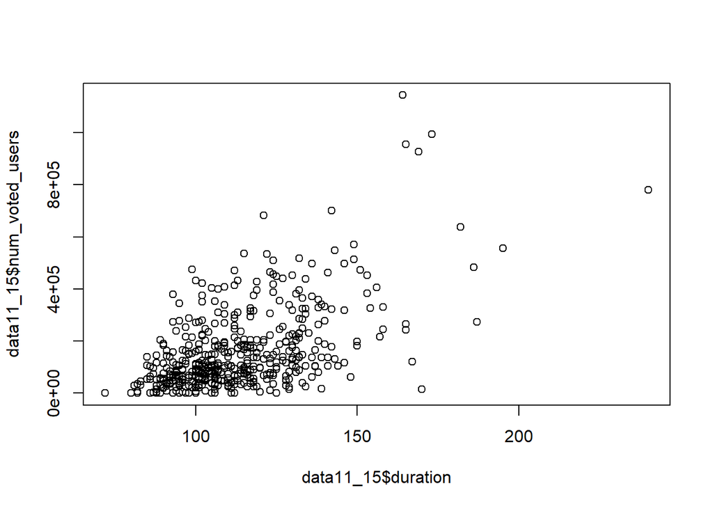

```r
plot(data11_15$duration, data11_15$num_voted_users)
```

The final criteria we consider is film genre. This is not straightforward, as a film can belong to more than one category (e.g. a sci-fi, action thriller). We adopt a count-based approach, based on the number of times a description appears, although this may introduce an added source of multicollinearity.

### Commercial: Box office ticket sales

```r
log6_gross <- (log(data11_15$gross)^6)

rev_mod1 <- lm(data=data11_15, gross ~ (budget))
rev_mod2 <- lm(data=data11_15, gross ~ (budget + actiondummy + scifidummy + thrillerdummy + romancedummy + comedydummy + familydummy))
rev_mod3 <- lm(data=data11_15, gross ~ (budget + actiondummy + scifidummy + duration))
rev_mod4 <- lm(data=data11_15, gross ~ (budget + actiondummy + scifidummy + actor_oscars + dir_oscars + movie_oscars +
                                          sum_actor_occurence + director_occurence))
rev_mod5 <- lm(data=data11_15, gross ~ (budget + actiondummy + scifidummy + sum_actor_occurence + director_occurence))
rev_mod6 <- lm(data=data11_15, gross ~ (budget + actiondummy + scifidummy + sum_actor_occurence + director_occurence + num_voted_users))
rev_mod7 <- lm(data=data11_15, log6_gross ~ (budget + actiondummy + scifidummy + sum_actor_occurence + director_occurence))
rev_mod8 <- lm(data=data11_15, log6_gross ~ (budget + actiondummy + scifidummy + sum_actor_occurence + director_occurence + num_voted_users))

stargazer(rev_mod1, rev_mod2, rev_mod3, rev_mod4, rev_mod5, rev_mod6, rev_mod7, rev_mod8, type = "html", report = "vct*")
```

[output not shown]

[output cut: 19 more lines]

Coming to the finding the determinants of financial popularity or revenue of a movie, we begin with a simple quation trying to analyse the impact of the budget of the movie. This regression model, with an adjusted $R^2$ value is ~0.461 and a very low p-value, determines budget as a very significant factor affecting revenues.

Refining the equation (4) we derive regression equation (5) with adjusted $R^2$ value as ~0.491, meaning it fits for 49% of our data. Adding the variable for social success of the movie in equation (6), which is the number of voted users variable, we observe that the adjusted $R^2$ increases to ~0.605 and at the same time decreasing the RSE value significantly. We also observe that by adding the number of voted users variable, the scifi_genre variable and the sum_actor_occurence variable looses its significance to the revenue. Although it is not the optimal equation, we feel that within the data limitations, this fit gives us the most meaningful ‘best-fit’ equation.

Taking into account the skew in the data, we further refine our model in equations (7) and (8) by replacing the gross variable with its log^6 equivalent in order to ensure that our regression is free from bias.

## Section 5: Hypothesis testing and robustness

```r
log4numvoted_users <- (log(data11_15$num_voted_users)^4)
Usereg11 <- lm(data = data11_15, log4numvoted_users ~ gross + actor_oscars + familydummy + scifidummy)
log4numvoted_users <- (log(data16$num_voted_users)^4)
Usereg12 <- lm(data = data16, log4numvoted_users ~ gross + actor_oscars + familydummy + scifidummy)

stargazer(Usereg11, Usereg12, type = 'text')
```

=================================================================== Dependent variable:  
———————————————– log4numvoted_users  
(1) (2)  
——————————————————————- gross 0.00004*** 0.00004***  
(0.00000) (0.00001)

actor_oscars 1,981.549*** 389.544  
(282.306) (972.299)

familydummy -3,619.475*** -1,923.152  
(688.663) (1,942.806)

scifidummy 1,770.747*** 2,286.387  
(602.271) (1,507.722)

Constant 13,520.700*** 8,434.158***  
(333.241) (891.420)

Observations 498 37  
R2 0.476 0.694  
Adjusted R2 0.472 0.656  
Residual Std. Error 4,854.984 (df = 493) 3,393.353 (df = 32)  
F Statistic 112.047*** (df = 4; 493) 18.149*** (df = 4; 32) =================================================================== Note: *p<0.1; **p<0.05;*** p<0.01

```r
t.test(data11_15$familydummy, data16$familydummy, alternative='two.sided')
```

```
Welch Two Sample t-test
```

data: data11_15$familydummy and data16$familydummy t = 0.30448, df = 42.117, p-value = 0.7623 alternative hypothesis: true difference in means is not equal to 0 95 percent confidence interval: -0.0922345 0.1250143 sample estimates: mean of x mean of y 0.1244980 0.1081081

```r
t.test(data11_15$gross, data16$gross, alternative='two.sided')
```

```
Welch Two Sample t-test
```

data: data11_15$gross and data16$gross t = -0.88418, df = 41.159, p-value = 0.3817 alternative hypothesis: true difference in means is not equal to 0 95 percent confidence interval: -45712967 17871570 sample estimates: mean of x mean of y 80765853 94686551

```r
t.test(data11_15$gross, data16$gross, alternative='two.sided')
```

```
Welch Two Sample t-test
```

data: data11_15$gross and data16$gross t = -0.88418, df = 41.159, p-value = 0.3817 alternative hypothesis: true difference in means is not equal to 0 95 percent confidence interval: -45712967 17871570 sample estimates: mean of x mean of y 80765853 94686551

```r
t.test(data11_15$scifidummy, data16$scifidummy, alternative='two.sided')
```

```
Welch Two Sample t-test
```

data: data11_15$scifidummy and data16$scifidummy t = -2.0958, df = 39.462, p-value = 0.04257 alternative hypothesis: true difference in means is not equal to 0 95 percent confidence interval: -0.335246315 -0.006010605 sample estimates: mean of x mean of y 0.1807229 0.3513514

## Section 6: Limitations

Being unable to source separate details on financial characteristics on each film has further hindered this process, whilst limiting our ability to investigate the full value chain. Examples of other financial characteristics we wanted to appraise include:

- A breakdown of budget expenses - marketing: understanding spend to promote films prior to release, and upon the immediate release of a film. This includes the amount spent on social media platforms, relative to conventional mediums (e.g. newspaper ads; TV commercials, etc), to better understand how this affects the perception of popularity and contributes to revenues
- A breakdown of budget expenses - pre / post production costs: including salaries for the leading actor(s) / supporting actors. This would better approximate the value of an actor, including their perception of popularity, representing a more apt variable relative to counting the number of actor occurences between 2011-16 (see below).
- DVD, in-film advertising, merchandise sales, and any cash subsidies: To gauge financial success, understanding the contribution of other revenue streams to determining overall pre-tax returns on investment. This also applies to any direct government incentives (e.g. subsidies) to support the production of films. This data is likely to boost the significance of our ROI estimator.

Another limitation was our inability to specify a single genre for each film. Our dataset classified each film across multiple genres, resulting in our dummy variables potentially lacking in sufficient power from diluting their relevance. It was thus a surprise to learn that family films were statistically more significant than action, comedy, romance, or thrillers, which were all well represented within our sample. We may thus have introduced error into our residual, which we would seek to correct in future from either a third party classification source, and / or from performing key-word count searches on film synopses.

## Section 7: Conclusions and next steps

In terms of developing our study, we would like to understand how these findings apply to arthouse films.

## Appendix 2 - Data cleaning methodology

We discuss the steps taken in cleaning our underlying datasets prior to analysis:  
* **IMDB Movie Dataset**  
* **Oscar Awards Dataset** * **Compilation of both Datasets**

1. **IMDB Movie Dataset:** The raw data consisted of 5044 observations, containing details of movies from the IMDb database over 28 variables. These variables included information about the movie performance on the box office, the actor(s) name, director(s) names, movie genre, movie facebook likes and more.
   - **Step 1 - Cleaning up inconsistent observations:** The raw dataset contained a lot of inconsistencies, namely ‘NA’ or Blank values for several observations. In order to get a consistent data to perform analysis on, we *removed all the observations with any NA or blank values*.
   - **Step 2 - Removing duplicate values:** We observed that the dataset contained duplicate observations, which were also removed.
   - **Step 3 - Limiting our dataset:** In order to do a comprehensive analysis, having a dataset of movies belonging to a single country or industry will be a good place to start. Furthermore, ever since the the outset of facebook and other social media, the success of a movie is heavily reliant on its social presence and digital marketing. Therefore, to completely account for these factors, and also ensure that the data we analysed is consistent, we have limited our data to *movies made in the USA after the year 2011*.
   - **Step 4 - Segregating the movie genres:** The dataset contained the movie genres in the form of a single string, with every genre of the movie, delimited by a ‘|’ symbol. In order to get the actual genres separated and ready to use, we used created flags in order to check whether the movie is of a particular genre. For example: the ‘action_genre’ column will have a 1 value for an observation, if it is an action movie.
   - **Step 5 - Calculating the number of occurences of each actor/director:** Another interesting variable that we expect to be of significance to our analysis was the number of times an actor/director has showed up in our dataset. That data would allow us to possibly find interesting points on how an actor/director can impact a movie’s performance/success. Thus, we added variables/columns with the *number of occurences for actors and directors*.
   - **Step 6 - Calculating the movie ROI:** We add another variable, ‘movie_roi’ which contains the *return on investment for each movie*. This will help us in our analysis.
   - **Step 7 - Selecting only the required columns:** The raw dataset consisted of 28 variables, many of which are not required in our analyses. Thus, we remove the unwanted columns and keep only the data that is specific to our analysis. In the process we reduce the size of the dataset leading to better performance. (See data description for more detials).
2. **Oscar winners dataset:** The raw dataset of awards contained 2321 observations over 4 variables. This database consisted the nominees and winners of the Academy Awards (or Oscars) ever since its inception, i.e. from 1927 to 2015.
   - **Step 1 - Cleaning up inconsistent observations:** The raw dataset some inconsistent observations where the name of the winner and the film was placed in the incorrect column. Since this was the case for the initial few records only, we ignored this and copied the values in the ‘film’ column to the ‘names’ column.
   - **Step 2 - Limiting our dataset:** The dataset included both nominess and winner and from every category. We were interested in collecting data about the actors, directors, and the best picture winners only in order to see how that impacts the success of a movie. Therefore, we *excluded the nomiees and only kept the winners for the awards* related to Best Actor/Actress in a Lead/Supporting role, Best Director and Best Picutre.
   - **Step 3 - Counting the awards:** In order to get the data of the number of wins for each individual, we introduced a new column ‘num_wins’ which counted the *number of occurences of a name in the winners list*. Using this data makes sense as in order to asses the impact of this on a movies popularity/success.
   - **Step 4 - Selecting the required columns:** The raw dataset contains 4 variables, and a count column, out of which only the ‘count’ and ‘name’ column is required for our analysis. Thus we select only a small subset of the raw data for our analysis.  
     The cleaned awards data now has 434 observations over 2 variables. This data will come handy to check which movies/actors/directors have oscar(s) to their name(s) and how that impacts the success of a movie.
3. **Final (Cumulative) Dataset:** In order to get the final working database, we combine the information from the two cleaned datasets.
   - **Step 1 - Summarizing the datasets:** We need to get the number of award wins for actors, directors, and movie for each observation in the into the IMDB movie dataset, from the ‘Oscar winners dataset’. We do this by introducing new variables that captures *the count of oscars for each actor, director, and movie for each observation*.
   - **Step 2 - Diving the final data into two datasets:** The entire basis of our analysis was to create a model that can predict the success of a hollywood movie. To achieve that, we will try to build a model (or hypothesis) using the data for movies from 2011 to 2015 and then test the model (or hypothesis) for the movies in 2016. This will give us a clear indication of how our model fits with current and future data. Thus we *create two subsets of the final data, one for data of movies from 2011 to 2015 and the other with the data of movies for 2016*.

## Appendix 3 - Boxplots and Density graphs

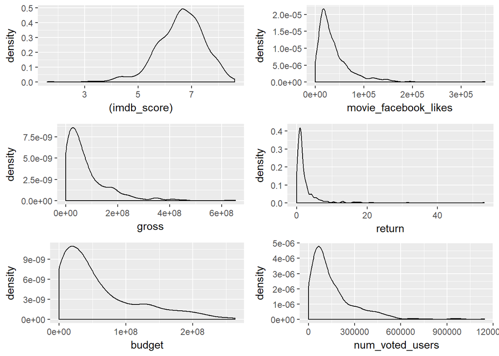

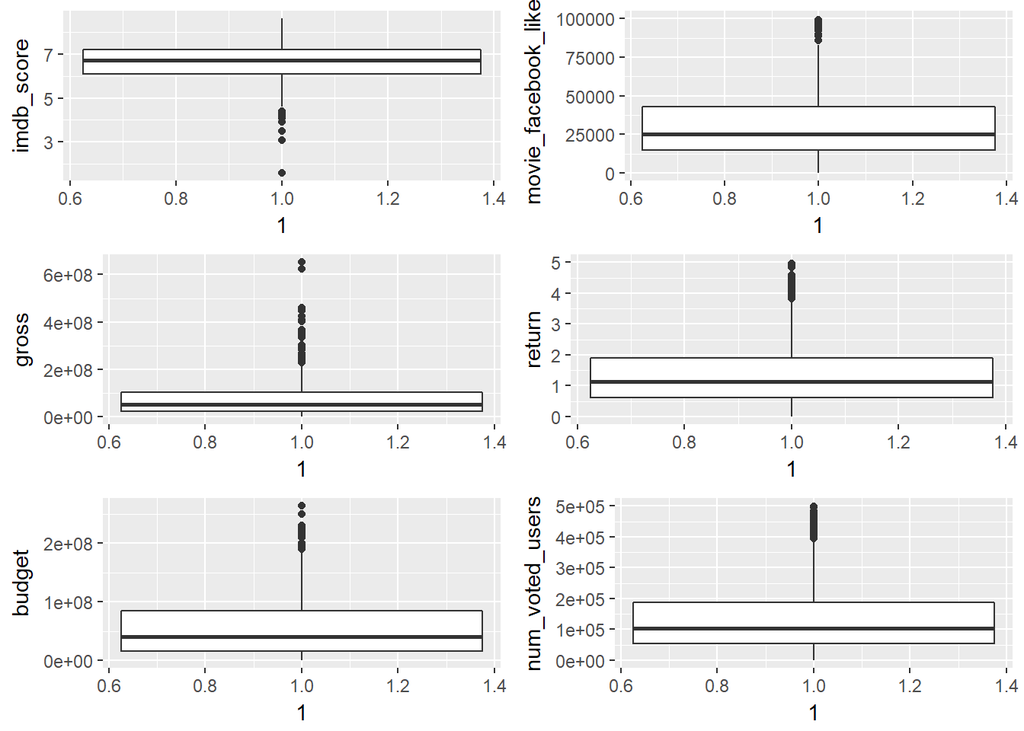

## Bibliography and references

We have made reference to various forums on coding best-practices, notably including Stackoverflow.com, and other relevant sources of R studio information available online. These have been cited during the main document, where they have been specific to our study, or represent the application of coding practices not within the Maths and Statistics Foundations for Analytics module. We have not referenced general R studio packages applied within this module (e.g. dplyr; stargazer; etc).

We obtained the original dataset, in conjunction with information on Oscar academy awards, from the following websites: https://www.kaggle.com/tmdb/tmdb-movie-metadata/data https://www.kaggle.com/theacademy/academy-awards

In terms of documents we have referenced:

[1-2] “Film industry in the US”, Statista, Dossier (2016) https://www.statista.com/study/11472/film-industry-in-the-united-states-statista-dossier/ [3] “The Interview”, Wikipedia page (2017) https://en.wikipedia.org/wiki/The_Interview#Pre-release_reaction

[^1]: Statista (2016)
[^2]: Statista (2016)
[^3]: Wikipedia (2017)